# Intro to DS - Linear Model part I

GWU Intro to Data Science DATS 6101

2022-11-23

# HW assignment

## Linear model - quantitative regressors

The exercise uses a bikeshare dataset called `BikeShare` on api.regression.fit, or as a local file `bikedata.csv`.

### Question 1

**Import the data, call it `bikeorig`**  
The `Date` variable is probably imported as factor level variable. In any case, let us remove `Date`, `Casual_Users`, and `Registered_Users` in the dataset and save it as a new datafame, call it `bike`. How many variables are in `bike`? How many of them are imported as `int`? Feel free to rename longer variable names into shorter ones for convenience.

Ans:- There are 11 variables in bike. There are 9 variables that are imported as int.

```r
library(dplyr)
bikeorig <- read.csv('bikedata.csv')
print(bikeorig)
bike <- select(bikeorig, -c("Date", "Casual.Users", "Registered.Users"))
names(bike)[names(bike) == 'Working.Day'] <- 'Workday'
names(bike)[names(bike) == 'Day.of.the.Week'] <- 'Day'
names(bike)[names(bike) == 'Weather.Type'] <- 'Weather'
print(bike)
print(ncol(bike))
print(length(select_if(bike, is.integer)))
```

### Question 2

**Select only the subset with `Hour` equal 16 only. Call it `bike16`**  
These are the afternoon rush hour data. How many observations are there? Ans:There are totally 730 such observations.

```r
bike16 <- subset(bike, Hour == 16)
print(nrow(bike16))
```

### Question 3

**Before building any models, we should make sure the variables are set up properly.**  
(This problem is solved for you. Codes are given below.)  
Which ones should be recorded as categorical? Convert them now before we proceed to the model building.

Note: After converting, the correlation function `cor()` will not work with categorical/factor variables. I would keep the original `bike16` dataframe as numeric, and use that to find the correlation matrix. Although technically correlation between categorical and numeric variables are not well defined in general, we can still get some useful information if the categorical variable is at least at ordinal level. See future discussion on using “Pearson” vs “Spearman” methods for correlation tests.

While the `cor()` function does not accept categorical variables (and therefore we cannot use it for `corrplot()`), the `lattice::pairs()` function does not complain about categorical columns. We can still use it to get a visual distribution of data values from it.

```r
bike_final = bike16
bike_final$Season = factor(bike16$Season)
#bike_final$Hour = factor(bike16$Hour)
bike_final$Holiday = factor(bike16$Holiday)
bike_final$Day = factor(bike16$Day)
bike_final$Workday = factor(bike16$Workday)
bike_final$Weather = factor(bike16$Weather)
str(bike16)
str(bike_final)
```

We decided to convert these variables into categorical (factor):  
`Season`, `Holiday`, `Day`, `Workday`, and `Weather`. Notice that the dataframe `bike16` still has all variables numerical, while the df `bike_final` include categorical columns that we just converted.

### Question 4

**Make a `pairs()` plot with all the variables (quantitative and qualitative).**

The `paris` plot on the new dataframe `bike_final` is given here:

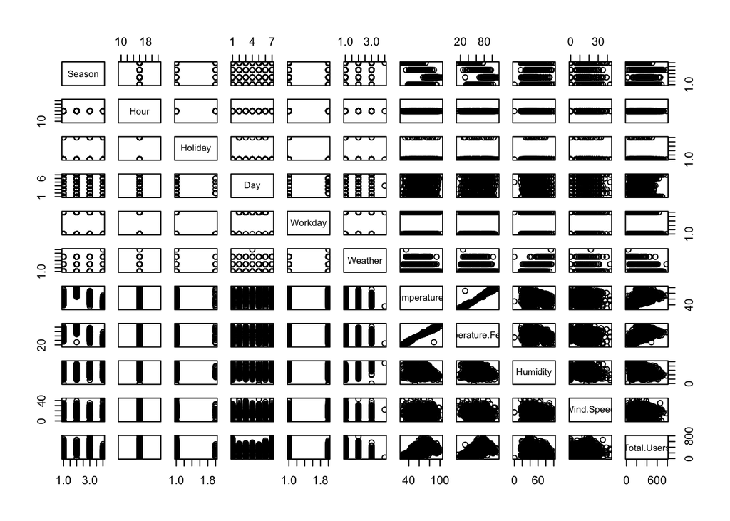

```r
loadPkg("lattice") # lattice and ggplot2 combined allow us to use the "pairs" function below
pairs(bike_final)
```

```r
# unloadPkg("lattice")
```

### Question 5

**Make a `corrplot()` with only the numerical variables.**  
You can either subset the df with only numerical variables first, then create the cor-matrix to plot. Or you can create the cor-matrix from `bike16`, then select select out the portion of the matrix that you want. Use options that shows well the relationships between different variables.

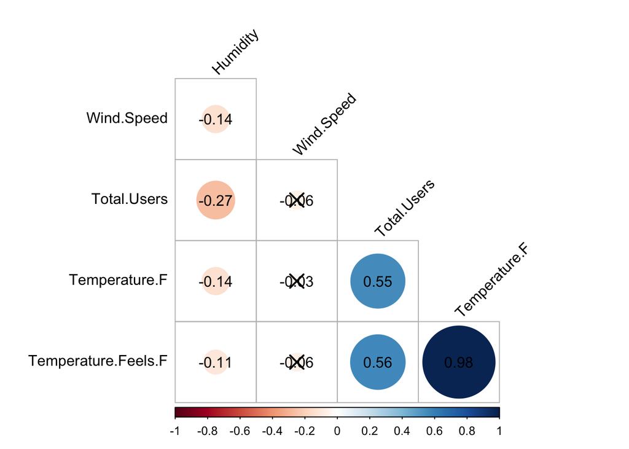

```r
num_data <- select_if(bike_final, is.numeric)
corr <- num_data %>% cor_mat(-Hour)
p_val <- num_data %>% cor_mat(-Hour) %>% cor_get_pval()
corr %>%
  cor_reorder() %>%
  pull_lower_triangle() %>%
  cor_plot(label = TRUE)
```

### Question 6

**By using numerical variables only, build a linear model with 1 independent variable to predict the `Total Users`.**  
Choose the variable with the strongest correlation coefficient. Make some short comments on the coefficient values, their p-values, and the multiple R-squared value.

Ans:- The feature Temperature.Feels.F has the strongest correlation in the dataframe. Intercept of the model is 44.53 and the corresponding p-value is 0.0042. The coefficient of the independent variable temperature is 4.02 while its p-value is 2e-16. The R square value is 0.308.

```r
model1 <- lm(Total.Users ~ Temperature.Feels.F, data = bike_final)
xkabledply(model1, title = "Model1")
```

### Question 7

**Next, add a second variable to the model.**  
Choose the variable with the next strongest correlation, but avoid using obviously collinear variables (`TempF` and `TempFF` for example). When you have the model, check the VIF values. If the VIF is higher than 5, discard this model, and try the variable with the next strongest correlation until you find one that works (ideally with vif’s <5, or if you have to, allow vif up to 10). Again, comment on the coefficient values, their p-values, and the multiple R-squared value.

Ans:- We add the second feature humidity for model 2 whose intercept value is 138.71. The coefficients for temperature and humidity are 3.86 and -1.68 respectively. The R square value of the model is 0.352 which is slightly higher than model-1.

```r
model2 <- lm(Total.Users ~ Temperature.Feels.F + Humidity, data = bike_final)
xkabledply(model2, title = "Model2")
xkablevif(model2)
```

### Question 8

**We will try one more time as in the previous question, to add a third variable in our model.**  
Ans:- Temperature.F cannot be used as a feature for colinearity with Temperature.Feels.F as the p-value of 0.6135 is not significant enough for this feature.

```r
model3 <- lm(Total.Users ~ Temperature.Feels.F + Humidity + Temperature.F, data = bike_final)
xkabledply(model3, title = "Model3")
xkablevif(model3)
```

### Question 9

**For the 3-variable model you found, find the confidence intervals of the coefficients.**

```r
xkabledply(confint(model3))
```